# Monk Monastery Network

A closer look into Samson dataset

Peter Sullivan  
2022-02-17

## Introduction to Dataset

The following data set looks at social interactions amoung monks. This data was recorded in 1969. During Sampsons stay at a monestary, 4 monks were expelled from the monestary. Sampson interviewed the monks about positive relations between monks. Each monk ranked their top three choices. A tie is represented by monks liking another monk. The data was gathered three times to see if group sentiment changed over time.

## Describe the Network

```r
ls()
```

```
[1] "network_igraph"  "network_nodes"   "network_statnet"
```

```r
print(network_statnet)
```

```
 Network attributes:
  vertices = 18
  directed = TRUE
  hyper = FALSE
  loops = FALSE
  multiple = FALSE
  total edges= 88
    missing edges= 0
    non-missing edges= 88

 Vertex attribute names:
    cloisterville group vertex.names

 Edge attribute names:
    nominations
```

```r
vcount(network_igraph)
```

```
[1] 18
```

```r
ecount(network_igraph)
```

```
[1] 88
```

Both the igraph and statnet datasets are showing the same number of nodes and edges. 18 nodes and 88 edges.

```r
is_bipartite(network_igraph)
```

```
[1] FALSE
```

```r
is_directed(network_igraph)
```

```
[1] TRUE
```

```r
is_weighted(network_igraph)
```

```
[1] FALSE
```

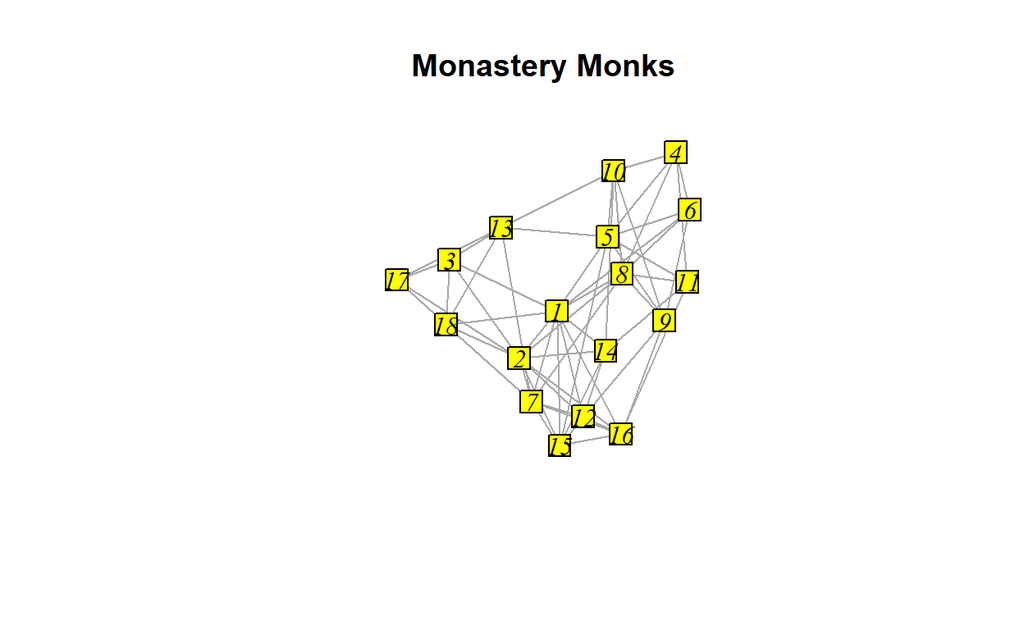

```r
V(network_igraph)$color = "yellow"


plot(
  network_igraph,
  edge.arrow.mode = .9,
  vertex.label.color = "black",
  vertex.shape = "square",
  vertex.label.font = 3,
  main = "Monastery Monks"

)
```

We have a single mode, directed, and unweighted dataset.

## Looking at the Attributes

```r
igraph::vertex_attr_names(network_igraph)
```

```
[1] "cloisterville" "group"         "na"            "vertex.names"
[5] "color"
```

```r
network::list.vertex.attributes(network_statnet)
```

```
[1] "cloisterville" "group"         "na"            "vertex.names"
```

```r
igraph::edge_attr_names(network_igraph)
```

```
[1] "na"          "nominations"
```

```r
network::list.edge.attributes(network_statnet)
```

```
[1] "na"          "nominations"
```

Both statnet and igraph are showing the same results. The vertex attribute names are cloisterville, group and vertex.names. There are three types of groups, Loyal, Outcasts and Turks. Cloisterville is indicated by true or false and it represents whether the monk was in the seminary of Cloisterville before coming the the present monestary.

## Looking into the attribute data

```r
V(network_igraph)$vertex.names %>% head()
```

```
[1] "John Bosco"  "Gregory"     "Basil"       "Peter"
[5] "Bonaventure" "Berthold"
```

```r
network_statnet %v% "vertex.names" %>% head()
```

```
[1] "John Bosco"  "Gregory"     "Basil"       "Peter"
[5] "Bonaventure" "Berthold"
```

```r
V(network_igraph)$cloisterville %>% head()
```

```
[1]  TRUE  TRUE  TRUE  TRUE  TRUE FALSE
```

```r
V(network_igraph)$group %>% head()
```

```
[1] "Turks"    "Turks"    "Outcasts" "Loyal"    "Loyal"    "Loyal"
```

```r
V(network_igraph)$vertex.names %>% length()
```

```
[1] 18
```

We are able to retrieve all 18 of the monks names.

```r
E(network_igraph)$nominations %>% head()
```

```
[1] 1 1 1 1 3 3
```

```r
network_statnet %e% "nominations" %>% head()
```

```
[1] 1 1 1 1 3 3
```

```r
E(network_igraph)$nominations %>% unique() %>% sort()
```

```
[1] 1 2 3
```

The edge attributes seem to be numbers ranging form 1 to 3.

## Summarizing Network Attriubtes

```r
summary(E(network_igraph)$nominations)
```

```
   Min. 1st Qu.  Median    Mean 3rd Qu.    Max.
  1.000   1.000   2.000   1.909   3.000   3.000
```

## Dyad Census

```r
igraph::dyad.census(network_igraph)
```

```
$mut
[1] 28

$asym
[1] 32

$null
[1] 93
```

```r
sna::dyad.census(network_statnet)
```

```
     Mut Asym Null
[1,]  28   32   93
```

Both network and igraph are getting the same results. Since each monk was each recommending the top three of each, I’m surprised by how many mutual ties there are.

## Triad Census

```r
igraph::triad_census(network_igraph)
```

```
 [1] 167 205 190  12  24  24  68  34   5   0  35  15   6   5  18   8
```

```r
sna::triad.census(network_statnet)
```

```
     003 012 102 021D 021U 021C 111D 111U 030T 030C 201 120D 120U
[1,] 167 205 190   12   24   24   68   34    5    0  35   15    6
     120C 210 300
[1,]    5  18   8
```

## Transitivity

```r
transitivity(network_igraph, type = "global")
```

```
[1] 0.4646739
```

```r
transitivity(network_igraph, type = "average")
```

```
[1] 0.4925926
```

## Geodesic Paths

```r
average.path.length(network_igraph)
```

```
[1] 1.996732
```

This is to be expected with such a small network.

## Component Structure

```r
names(igraph::components(network_igraph))
```

```
[1] "membership" "csize"      "no"
```

```r
igraph::components(network_igraph)$no
```

```
[1] 1
```

```r
igraph::components(network_igraph)$csize
```

```
[1] 18
```

```r
igraph::components(network_igraph)$membership
```

```
 [1] 1 1 1 1 1 1 1 1 1 1 1 1 1 1 1 1 1 1
```

## Isolates

```r
isolates(network_statnet)
```

```
integer(0)
```

There are no isolates. This means there are no monks that don’t like any monks or are liked by other monks.

## Density

```r
graph.density(network_igraph)
```

```
[1] 0.2875817
```

```r
network.density(network_statnet)
```

```
[1] 0.2875817
```

Both Network densitys are the same for both igraph and statnet. The denisty is low, but this is to be expected, since each monk could only pick 3 other monks.

## Degrees

```r
x <- data.frame(
  Name = network_statnet %v% "vertex.names",
  Total_Degrees = sna::degree(network_statnet),
  Out_Degrees = sna::degree(network_statnet, cmode = "indegree"),
  in_Degrees = sna::degree(network_statnet, cmode = "outdegree")

)

x %>% arrange(desc(Total_Degrees)) %>% head()
```

```
         Name Total_Degrees Out_Degrees in_Degrees
1  John Bosco            17          11          6
2     Gregory            15          10          5
3 Bonaventure            13           8          5
4        Mark            11           6          5
5      Victor            11           5          6
6     Winfrid            11           7          4
```

```r
x %>% arrange(Total_Degrees) %>% head()
```

```
      Name Total_Degrees Out_Degrees in_Degrees
1 Berthold             6           2          4
2    Elias             6           2          4
3    Basil             8           3          5
4  Ambrose             8           4          4
5  Romauld             8           2          6
6    Louis             8           3          5
```

```r
x %>% arrange(in_Degrees)
```

```
          Name Total_Degrees Out_Degrees in_Degrees
1        Amand             8           5          3
2        Peter             9           5          4
3     Berthold             6           2          4
4      Ambrose             8           4          4
5      Winfrid            11           7          4
6        Elias             6           2          4
7      Gregory            15          10          5
8        Basil             8           3          5
9  Bonaventure            13           8          5
10        Mark            11           6          5
11       Louis             8           3          5
12        Hugh            11           6          5
13      Albert             8           3          5
14  John Bosco            17          11          6
15      Victor            11           5          6
16     Romauld             8           2          6
17    Boniface             9           3          6
18  Simplicius             9           3          6
```

```r
x %>% arrange(Out_Degrees)
```

```
          Name Total_Degrees Out_Degrees in_Degrees
1     Berthold             6           2          4
2      Romauld             8           2          6
3        Elias             6           2          4
4        Basil             8           3          5
5        Louis             8           3          5
6     Boniface             9           3          6
7       Albert             8           3          5
8   Simplicius             9           3          6
9      Ambrose             8           4          4
10       Peter             9           5          4
11      Victor            11           5          6
12       Amand             8           5          3
13        Mark            11           6          5
14        Hugh            11           6          5
15     Winfrid            11           7          4
16 Bonaventure            13           8          5
17     Gregory            15          10          5
18  John Bosco            17          11          6
```

Everybody must love John Bosco. Berthold and Elias were very much disliked. Berthold, Elias and Basil were apart of the 4 monks that were expelled from the monestary. It seems that those with the smallest out degrees were the ones to expelled.

```r
summary(x %>% select(-Name))
```

```
 Total_Degrees     Out_Degrees       in_Degrees
 Min.   : 6.000   Min.   : 2.000   Min.   :3.000
 1st Qu.: 8.000   1st Qu.: 3.000   1st Qu.:4.000
 Median : 9.000   Median : 4.500   Median :5.000
 Mean   : 9.778   Mean   : 4.889   Mean   :4.889
 3rd Qu.:11.000   3rd Qu.: 6.000   3rd Qu.:5.750
 Max.   :17.000   Max.   :11.000   Max.   :6.000
```

The lowest degrees were 6, while on average, each monk had ~5 out and indegrees.

## Degree Distribution

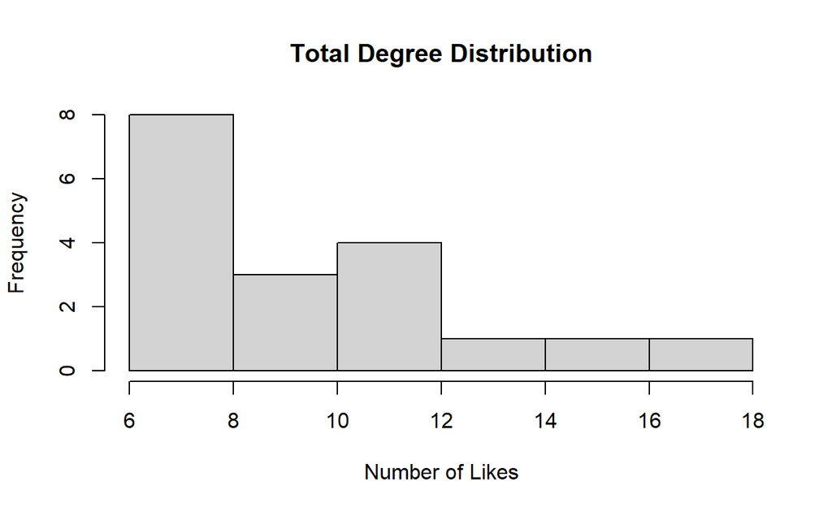

```r
hist(x$Total_Degrees, main = "Total Degree Distribution",
     xlab = "Number of Likes")
```

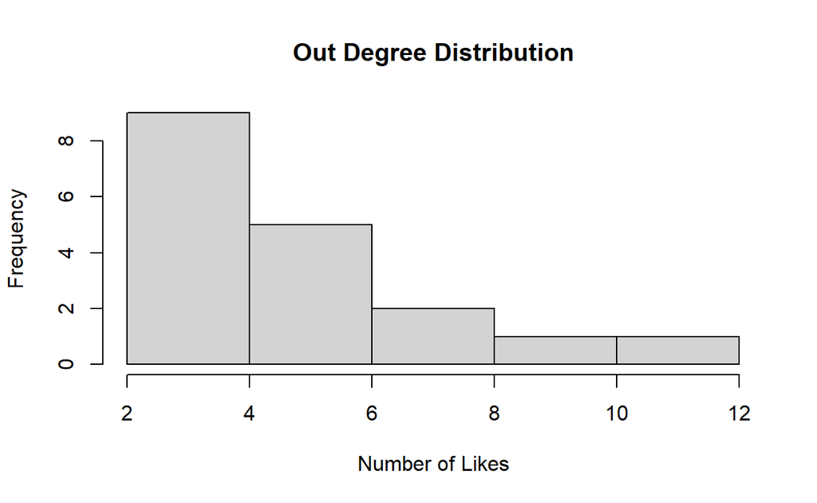

```r
hist(x$Out_Degrees, main = "Out Degree Distribution",
     xlab = "Number of Likes")
```

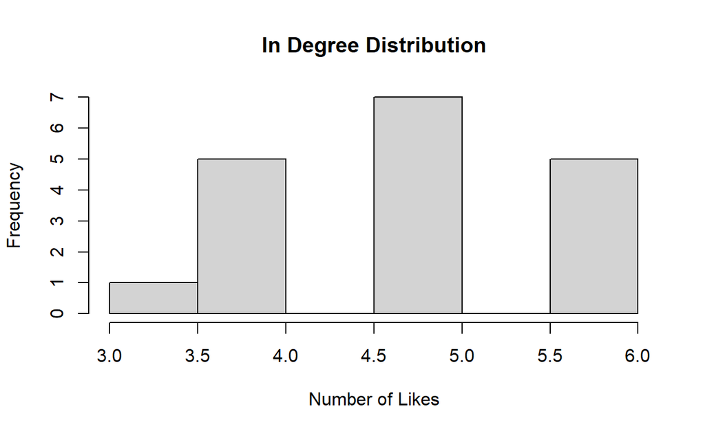

```r
hist(x$in_Degrees, main = "In Degree Distribution",
     xlab = "Number of Likes")
```

## Degree Centralization

```r
centr_degree(network_igraph, loops = FALSE, mode ="in")
```

```
$res
 [1] 11 10  3  5  8  2  6  5  4  2  3  7  5  6  3  3  2  3

$centralization
[1] 0.3806228

$theoretical_max
[1] 289
```

```r
centr_degree(network_igraph, loops = FALSE, mode = "out")
```

```
$res
 [1] 6 5 5 4 5 4 5 6 4 6 5 4 3 5 6 5 4 6

$centralization
[1] 0.06920415

$theoretical_max
[1] 289
```

The indegree centralization is at 38 % while the out degree is at 7%.

## Eigenvector Centrality

```r
x$eigen <- sna::evcent(network_statnet)

x %>% arrange(eigen)
```

```
          Name Total_Degrees Out_Degrees in_Degrees     eigen
1        Amand             8           5          3 0.1479037
2     Berthold             6           2          4 0.1711191
3        Peter             9           5          4 0.1717189
4        Elias             6           2          4 0.1833911
5      Ambrose             8           4          4 0.1900849
6  Bonaventure            13           8          5 0.2061513
7      Winfrid            11           7          4 0.2138861
8        Basil             8           3          5 0.2313738
9        Louis             8           3          5 0.2334813
10     Romauld             8           2          6 0.2481996
11        Mark            11           6          5 0.2591275
12        Hugh            11           6          5 0.2592391
13     Gregory            15          10          5 0.2635120
14      Albert             8           3          5 0.2643663
15      Victor            11           5          6 0.2664155
16  Simplicius             9           3          6 0.2745468
17  John Bosco            17          11          6 0.2879960
18    Boniface             9           3          6 0.2978587
```

## Bonacich Power Centrality

```r
library(DT)
x$Bonach_Power <- power_centrality(network_igraph)
x$Bon_pow <- sna::bonpow(network_statnet)

x %>% DT::datatable()
```

|  | Name | Total_Degrees | Out_Degrees | in_Degrees | eigen | Bonach_Power | Bon_pow |
| --- | --- | --- | --- | --- | --- | --- | --- |
| 1 | John Bosco | 17 | 11 | 6 | 0.287995960973052 | -1.42155092108412 | -1.42155092108411 |
| 2 | Gregory | 15 | 10 | 5 | 0.263512041683265 | -0.684824226688595 | -0.684824226688599 |
| 3 | Basil | 8 | 3 | 5 | 0.23137382298106 | -1.37829886466168 | -1.37829886466168 |
| 4 | Peter | 9 | 5 | 4 | 0.171718943308207 | -1.26007657710702 | -1.26007657710701 |
| 5 | Bonaventure | 13 | 8 | 5 | 0.206151324404231 | -1.07553446970461 | -1.07553446970461 |
| 6 | Berthold | 6 | 2 | 4 | 0.171119148648865 | -1.05679191192156 | -1.05679191192156 |
| 7 | Mark | 11 | 6 | 5 | 0.259127539555084 | -0.596878378629638 | -0.596878378629644 |
| 8 | Victor | 11 | 5 | 6 | 0.266415461646183 | -1.21682452068458 | -1.21682452068458 |
| 9 | Ambrose | 8 | 4 | 4 | 0.19008488030372 | -0.321506952740119 | -0.321506952740126 |
| 10 | Romauld | 8 | 2 | 6 | 0.248199602384464 | -1.00488944421463 | -1.00488944421464 |

[output cut: 8 more lines]

## Creating Derived and Centrality Scores

```r
MatSamson <- as.matrix(as_adjacency_matrix(network_igraph, attr = "nominations"))

MatSamsonsq<- t(MatSamson) %*% MatSamson
x$rc <- diag(MatSamsonsq)/rowSums(MatSamsonsq)
x$rc <- ifelse(is.nan(x$rc),0,x$rc)
x$eigen.rc <- x$eigen*x$rc

x$dc <- 1 - diag(MatSamsonsq)/rowSums(MatSamsonsq)
x$dc <- ifelse(is.nan(x$dc),1,x$dc)
x$eigen.dc <- x$eigen*x$dc


x%>% arrange(Total_Degrees)
```

```
          Name Total_Degrees Out_Degrees in_Degrees     eigen
1     Berthold             6           2          4 0.1711191
2        Elias             6           2          4 0.1833911
3        Basil             8           3          5 0.2313738
4      Ambrose             8           4          4 0.1900849
5      Romauld             8           2          6 0.2481996
6        Louis             8           3          5 0.2334813
7        Amand             8           5          3 0.1479037
8       Albert             8           3          5 0.2643663
9        Peter             9           5          4 0.1717189
10    Boniface             9           3          6 0.2978587
11  Simplicius             9           3          6 0.2745468
12        Mark            11           6          5 0.2591275
13      Victor            11           5          6 0.2664155
14     Winfrid            11           7          4 0.2138861
```

[output cut: 23 more lines]

## Centrality Score Distributions

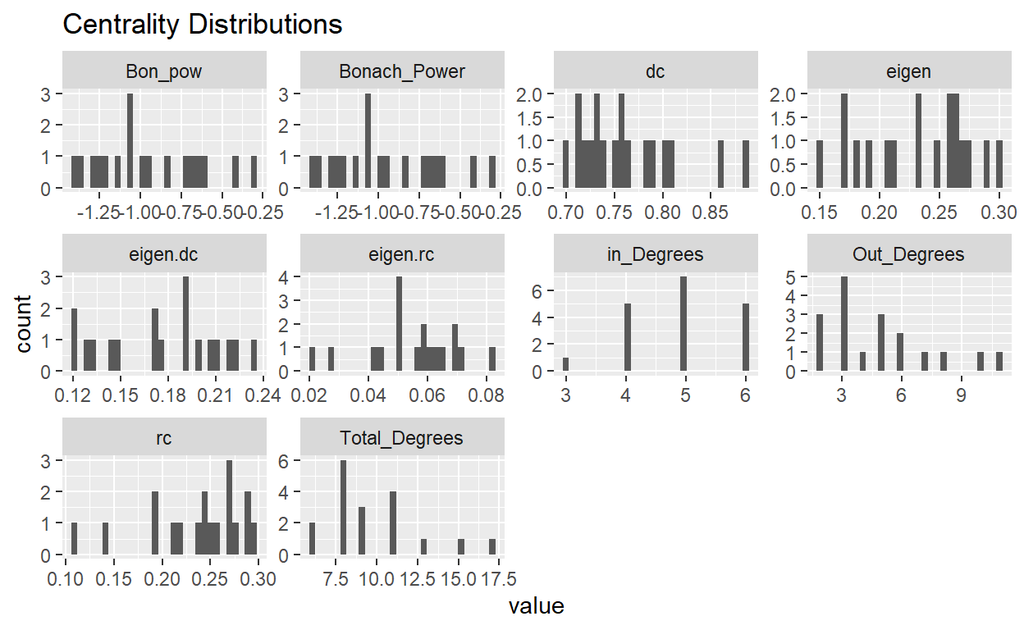

```r
library(ggplot2)
x %>% select(-Name)%>%
  gather()%>% ggplot(aes(value))+
  geom_histogram()+
  facet_wrap(~key, scales = "free")+
  ggtitle("Centrality Distributions")
```

## Centrality Measure Correlations

```r
library(corrplot)
temp <- x %>% select(Total_Degrees,in_Degrees,Out_Degrees, eigen, eigen.rc, eigen.dc, Bonach_Power) %>% cor()

temp
```

```
              Total_Degrees  in_Degrees  Out_Degrees      eigen
Total_Degrees     1.0000000  0.39262202  0.951760560  0.4898144
in_Degrees        0.3926220  1.00000000  0.091479857  0.8976743
Out_Degrees       0.9517606  0.09147986  1.000000000  0.2308543
eigen             0.4898144  0.89767426  0.230854298  1.0000000
eigen.rc          0.4138993  0.57257367  0.257121131  0.6628988
eigen.dc          0.4276075  0.86168397  0.175507168  0.9493956
Bonach_Power     -0.1269956 -0.38933451 -0.007610095 -0.1159809
                eigen.rc    eigen.dc Bonach_Power
Total_Degrees  0.4138993  0.42760750 -0.126995572
in_Degrees     0.5725737  0.86168397 -0.389334506
Out_Degrees    0.2571211  0.17550717 -0.007610095
eigen          0.6628988  0.94939557 -0.115980915
eigen.rc       1.0000000  0.39419648 -0.228543837
eigen.dc       0.3941965  1.00000000 -0.046490413
Bonach_Power  -0.2285438 -0.04649041  1.000000000
```

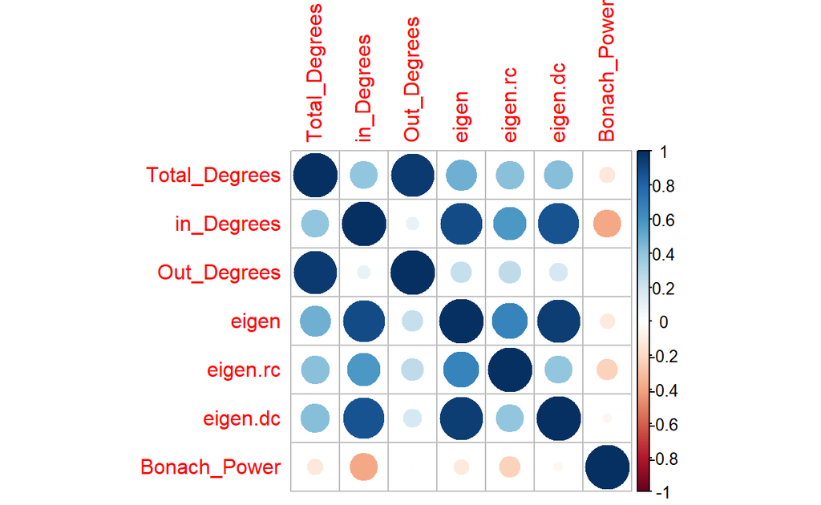

```r
corrplot(temp)
```